# OptionalRegressionPractice

GaryFH

May 1, 2017

#### See githup https://github.com/GaryFH/OPTIONALRegression-practice

# Overview

### This is an optional assignment the instructions follow:

##### “We are conducting research on the ways that people use data analysis and data science tools. Your participation in this non-graded and completely optional peer assessment will be part of that research. We will not collect any personally identifiable information about you for the purposes of this research and only aggregated totals of responses to questions will be reported. The potential risks to you are small. The potential benefits to the community of data scientists, developers, and professors are very high – we will be able to figure out which methods work and which methods do not. This exercise is 100% optional and will not have any influence whatsoever on your grade in the class. Thanks for considering helping us learn about data science!”

#### Note that some of the comments I used are partially copied from PennState’s STAT 501/Regression Methods and from “Quick Guide: Interpreting Simple Linear Model Output in R” by Felipe Rego - October 2015

## Get data, setup work environment and tidy

#### open from working directory

```r
library(dplyr)
```

```r
library(ggplot2)
data1<-read.csv("_cf0fd3361e05f5be5304b07b771bad48_companydata.csv", stringsAsFactors=F)
df1<-tbl_df(data1)
summary(df1)
```

```
##        y                x1               x2              x3
##  Min.   : 32.44   Min.   : 18.84   Min.   :20.15   Min.   :-76.175
##  1st Qu.:188.86   1st Qu.:123.71   1st Qu.:40.65   1st Qu.:-12.858
##  Median :274.45   Median :178.03   Median :58.10   Median :  8.846
##  Mean   :282.41   Mean   :184.90   Mean   :59.65   Mean   :  8.206
##  3rd Qu.:376.85   3rd Qu.:245.69   3rd Qu.:78.73   3rd Qu.: 29.737
##  Max.   :542.13   Max.   :339.12   Max.   :99.69   Max.   : 95.953
```

## Fun with graphs - plot x1, x2, x3 vrs y and show lm for each

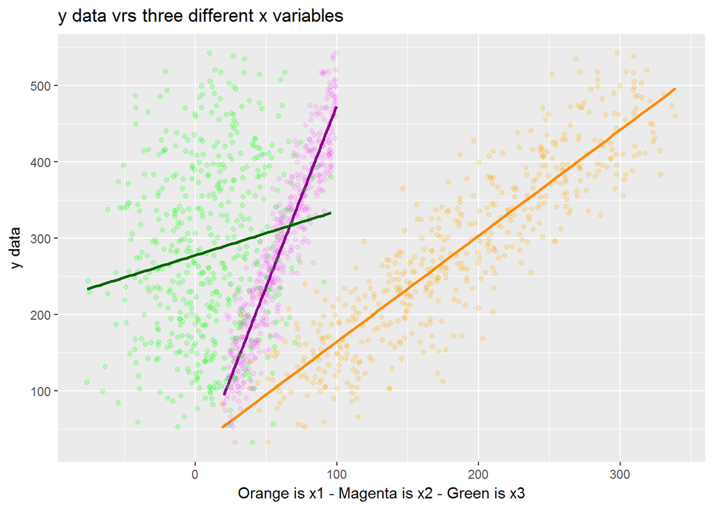

```r
        g<-ggplot()+
        geom_point(data=df1,aes(x=x1,y=y),alpha=.2,color="orange")+
        geom_smooth(data=df1,aes(x=x1,y=y),color="dark orange",method = lm, se=F)+
        geom_point(data=df1,aes(x=x2,y=y),alpha=.1,color="magenta")+
        geom_smooth(data=df1,aes(x=x2,y=y),color="dark magenta",method = lm, se=F)+
        geom_point(data=df1,aes(x=x3,y=y),alpha=.2,color="green")+
        geom_smooth(data=df1,aes(x=x3,y=y),color="dark green",method = lm, se=F)+
        labs(title="y data vrs three different x variables")+
        labs(x="Orange is x1 - Magenta is x2 - Green is x3",y="y data")
g
```

## Look at summary functions as follows:

### Multiple R-squared, Adjusted R-squared

##### The R-squared statistic (R^2) provides a measure of how well the model is fitting the actual data. It takes the form of a proportion of variance. The (R^2)is a measure of the linear relationship between our predictor variable (x) and our response / target variable (y). It always lies between 0 and 1 (i.e.: a number near 0 represents a regression that does not explain the variance in the response variable well and a number close to 1 does explain the observed variance in the response variable). In our example, the (R^2) we get is 0.7998. Or roughly 80% of the variance found in the response variable (y) can be explained by the predictor variable (x1). It should be noted that .8 indicates that x1 is a predictor of y. That why we get a relatively strong (R^2). Nevertheless, it’s hard to define what level of (R^2)is appropriate to claim the model fits well. Essentially, it will vary with the application and the domain studied. A side note: In multiple regression settings, the (R^2)will always increase as more variables are included in the model. That’s why the adjusted (R^2) is the preferred measure as it adjusts for the number of variables considered.

### F-Statistic

##### F-statistic is a good indicator of whether there is a relationship between our predictor and the response variables. The further the F-statistic is from 1 the better it is. However, how much larger the F-statistic needs to be depends on both the number of data points and the number of predictors. Generally, when the number of data points is large, an F-statistic that is only a little bit larger than 1 is already sufficient to reject the null hypothesis (H0 : There is no relationship between x1 and y). The reverse is true as if the number of data points is small, a large F-statistic is required to be able to ascertain that there may be a relationship between predictor and response variables. In our example the F-statistic is 1990 which is relatively larger than 1 given the size of our data.

```r
a1<-lm(y~x1,df1)
summary(a1)
```

```
##
## Call:
## lm(formula = y ~ x1, data = df1)
##
## Residuals:
##     Min      1Q  Median      3Q     Max
## -156.06  -33.13   -1.23   36.09  139.83
##
## Coefficients:
##             Estimate Std. Error t value Pr(>|t|)
## (Intercept) 25.94506    6.19828   4.186 3.36e-05 ***
## x1           1.38705    0.03109  44.610  < 2e-16 ***
## ---
## Signif. codes:  0 '***' 0.001 '**' 0.01 '*' 0.05 '.' 0.1 ' ' 1
##
## Residual standard error: 51.8 on 498 degrees of freedom
## Multiple R-squared:  0.7998, Adjusted R-squared:  0.7994
## F-statistic:  1990 on 1 and 498 DF,  p-value: < 2.2e-16
```

```r
a2<-lm(y~x2,df1)
summary(a2)
```

```
##
## Call:
## lm(formula = y ~ x2, data = df1)
##
## Residuals:
##      Min       1Q   Median       3Q      Max
## -127.963  -28.312    0.004   29.609  123.508
##
## Coefficients:
##             Estimate Std. Error t value Pr(>|t|)
## (Intercept)  -1.5783     5.2574   -0.30    0.764
## x2            4.7608     0.0824   57.78   <2e-16 ***
## ---
## Signif. codes:  0 '***' 0.001 '**' 0.01 '*' 0.05 '.' 0.1 ' ' 1
##
## Residual standard error: 41.72 on 498 degrees of freedom
## Multiple R-squared:  0.8702, Adjusted R-squared:  0.8699
## F-statistic:  3338 on 1 and 498 DF,  p-value: < 2.2e-16
```

```r
a3<-lm(y~x3,df1)
summary(a3)
```

```
##
## Call:
## lm(formula = y ~ x3, data = df1)
##
## Residuals:
##      Min       1Q   Median       3Q      Max
## -268.758  -91.529   -3.845   92.356  258.653
##
## Coefficients:
##             Estimate Std. Error t value Pr(>|t|)
## (Intercept) 277.6493     5.2840  52.546  < 2e-16 ***
## x3            0.5805     0.1624   3.575 0.000385 ***
## ---
## Signif. codes:  0 '***' 0.001 '**' 0.01 '*' 0.05 '.' 0.1 ' ' 1
##
## Residual standard error: 114.3 on 498 degrees of freedom
## Multiple R-squared:  0.02502,    Adjusted R-squared:  0.02306
## F-statistic: 12.78 on 1 and 498 DF,  p-value: 0.0003849
```

```r
a4<-lm(y~x1+x2,df1)
summary(a4)
```

```
##
## Call:
## lm(formula = y ~ x1 + x2, data = df1)
##
## Residuals:
##      Min       1Q   Median       3Q      Max
## -131.941  -28.231    0.108   30.473  123.991
##
## Coefficients:
##             Estimate Std. Error t value Pr(>|t|)
## (Intercept) -2.17846    5.27027  -0.413    0.680
## x1          -0.13253    0.09543  -1.389    0.166
## x2           5.18163    0.31402  16.501   <2e-16 ***
## ---
## Signif. codes:  0 '***' 0.001 '**' 0.01 '*' 0.05 '.' 0.1 ' ' 1
##
## Residual standard error: 41.68 on 497 degrees of freedom
## Multiple R-squared:  0.8707, Adjusted R-squared:  0.8702
## F-statistic:  1673 on 2 and 497 DF,  p-value: < 2.2e-16
```

```r
a5<-lm(y~x1+x2+x3,df1)
summary(a5)
```

```
##
## Call:
## lm(formula = y ~ x1 + x2 + x3, data = df1)
##
## Residuals:
##      Min       1Q   Median       3Q      Max
## -131.672  -28.472    0.597   30.258  123.630
##
## Coefficients:
##             Estimate Std. Error t value Pr(>|t|)
## (Intercept) -2.09331    5.28770  -0.396    0.692
## x1          -0.13048    0.09592  -1.360    0.174
## x2           5.17188    0.31705  16.313   <2e-16 ***
## x3           0.01418    0.06032   0.235    0.814
## ---
## Signif. codes:  0 '***' 0.001 '**' 0.01 '*' 0.05 '.' 0.1 ' ' 1
##
## Residual standard error: 41.72 on 496 degrees of freedom
## Multiple R-squared:  0.8707, Adjusted R-squared:  0.8699
## F-statistic:  1113 on 3 and 496 DF,  p-value: < 2.2e-16
```

## Look at “Residuals vrs Fitted” for the same alternatives shown above (and the some combined “x” variables).

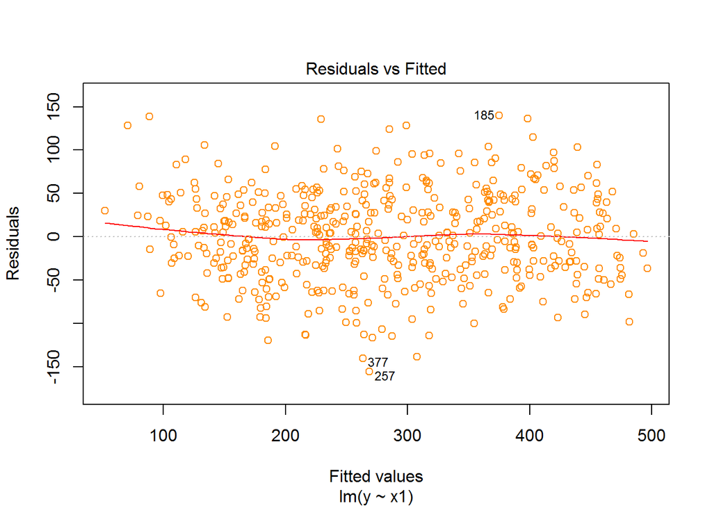

```r
plot(a1,which=1,col="dark orange")
```

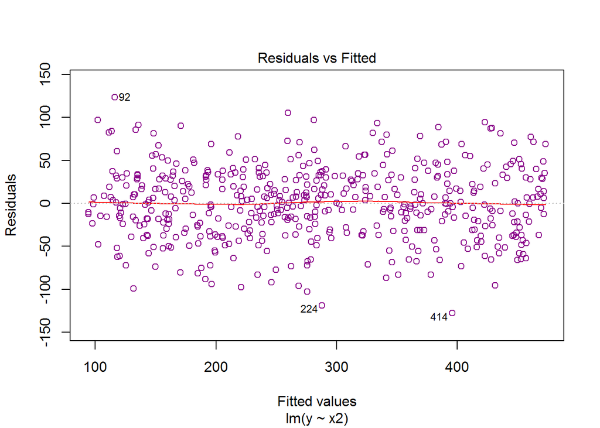

```r
plot(a2,which=1,col="dark magenta")
```

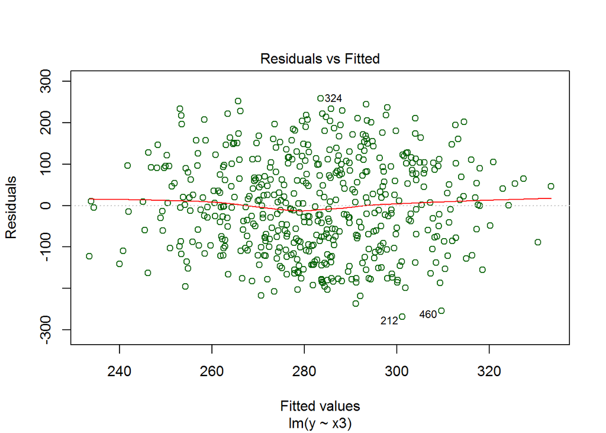

```r
plot(a3,which=1,col="dark green")
```

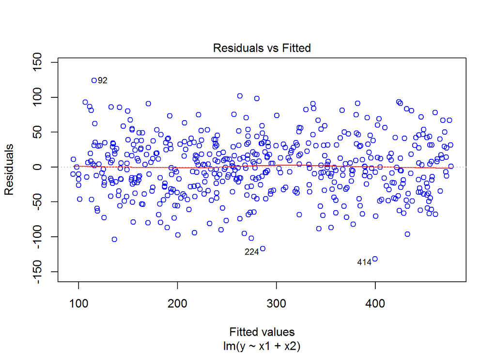

```r
plot(a4,which=1, col="blue")
```

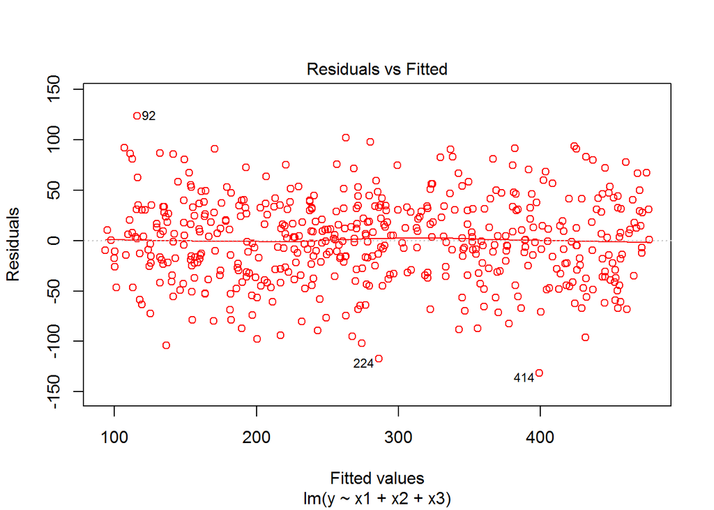

```r
plot(a5,which=1,col="red")
```

#### Note that, as defined, the residuals appear on the y axis and the fitted values appear on the x axis. You should be able to look back at the scatter plot of the data and see how the data points there correspond to the data points in the residual versus fits plot here. In case you’re having trouble with doing that, look at five specific data points in the original scatter plot. Note that the predicted response (fitted value) is consisant with the observed. Also, note the pattern in which the five data points deviate from the estimated regression line (brackets the line well). Now look at how and where these five data points appear in the residuals versus fits plot. Their deviation from the residual = 0 line shares the same pattern as their deviation from the estimated regression line. Do you see the connection? Any data point that falls directly on the estimated regression line has a residual of 0. Therefore, the residual = 0 line corresponds to the estimated regression line. Let’s take a look at that residuals versus fits plot again. All plots look like classical examples of a well-behaved residuals vs. fits plot.

## Here are the characteristics of a well-behaved residual vs. fits plot and what they suggest about the appropriateness of the simple linear regression model:

#### 1) The residuals “bounce randomly” around the 0 line. This suggests that the assumption that the relationship is linear is reasonable.

#### 2) The residuals roughly form a “horizontal band” around the 0 line. This suggests that the variances of the error terms are equal.

#### 4) No one residual “stands out” from the basic random pattern of residuals. This suggests that there are no outliers.

#### 5) In general, you want your residual vs. fits plots to look something like the above plot. Don’t forget though that interpreting these plots is subjective. My experience has been that students learning residual analysis for the first time tend to over-interpret these plots, looking at every twist and turn as something potentially troublesome. You’ll especially want to be careful about putting too much weight on residual vs. fits plots based on small data sets. Sometimes the data sets are just too small to make interpretation of a residuals vs. fits plot worthwhile.

# Summary

### Following gets confidence interval for y~x1 - you can calculate for lm()summary: The 95% confidence interval for the slope is the estimated coefficient (1.38705) ± two standard errors (0.03109) or as using confint:

```r
c1<-confint(a1,"x1",level = .95)
c2<-1.38705+c(-1,1)*(2*0.03109)
c1
```

```
##       2.5 %   97.5 %
## x1 1.325958 1.448135
```

```r
c2
```

```
## [1] 1.32487 1.44923
```